# Assignment2_Data608

# Visualization: Has the FED Fulfilled its Mandate?

# Unemployment, Inflation & Fed Funds Rate Trend

This line chart shows how the unemployment rate, inflation rate, and Fed Funds rate have changed over time.

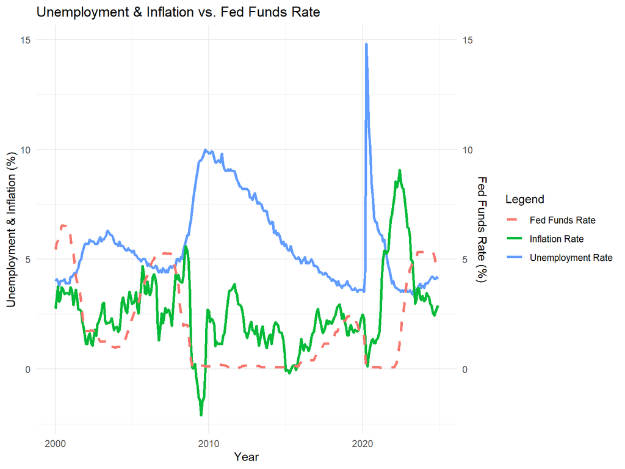

```r
# Create a combined plot with dual y-axes
ggplot(merged_df, aes(x = as.Date(paste(Year, Month, "1", sep = "-"), "%Y-%b-%d"))) +
  geom_line(aes(y = unemployment_rate, color = "Unemployment Rate"), size = 1.2) +
  geom_line(aes(y = inflation_rate, color = "Inflation Rate"), size = 1.2) +
  geom_line(aes(y = fed_fund_rate, color = "Fed Funds Rate"), size = 1.2, linetype = "dashed") +
  scale_y_continuous(sec.axis = sec_axis(~., name = "Fed Funds Rate (%)")) +
  labs(title = "Unemployment & Inflation vs. Fed Funds Rate",
       x = "Year",
       y = "Unemployment & Inflation (%)",
       color = "Legend") +
  theme_minimal()
```

### The Federal Reserve System has been given a dual mandate of pursuing the economic goals of maximum employment and price stability with a inflation rate of 2% over time and unemployment rate between 4% and 6% over time

# “Has the FED been able to fulfill the mandate given to it by Congress?”

# Unemployment Rate Over Time

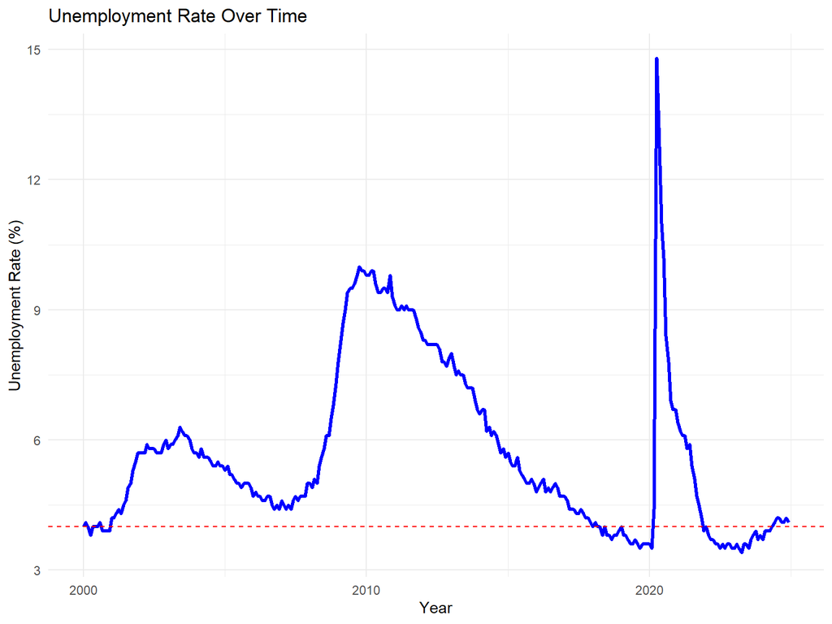

```r
ggplot(merged_df, aes(x = as.Date(paste(Year, Month, "1", sep = "-"), "%Y-%b-%d"), y = unemployment_rate)) +
  geom_line(color = "blue", size = 1.2) +
  geom_hline(yintercept = 4, linetype = "dashed", color = "red") +
  labs(title = "Unemployment Rate Over Time",
       x = "Year",
       y = "Unemployment Rate (%)") +
  theme_minimal()
```

# Inflation Rate Over Time

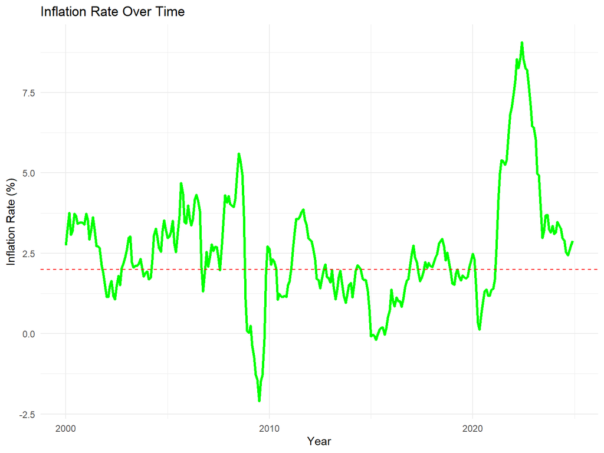

```r
ggplot(merged_df, aes(x = as.Date(paste(Year, Month, "1", sep = "-"), "%Y-%b-%d"), y = inflation_rate)) +
  geom_line(color = "green", size = 1.2) +
  geom_hline(yintercept = 2, linetype = "dashed", color = "red") +
  labs(title = "Inflation Rate Over Time",
       x = "Year",
       y = "Inflation Rate (%)") +
  theme_minimal()
```

Interpretation:

A dashed red line at 2% shows the price stability mandate If inflation stays near 2%, Fed is achieving price stability

To evaluate whether the Federal Reserve (FED) has met its unemployment mandate, we need to visualize unemployment trends over time and compare them with the “Achieved” vs. “Not Achieved” status.

```r
# Convert Month to numeric and create Date column
unemp_df <- unemp_df %>%
  mutate(
    Month = match(Month, month.abb),  # Convert "Jan" -> 1, "Feb" -> 2
    Date = as.Date(paste(Year, Month, "1", sep = "-"), format = "%Y-%m-%d"),
    unemployment_rate = as.numeric(unemployment_rate)  # Ensure numeric
  )
```

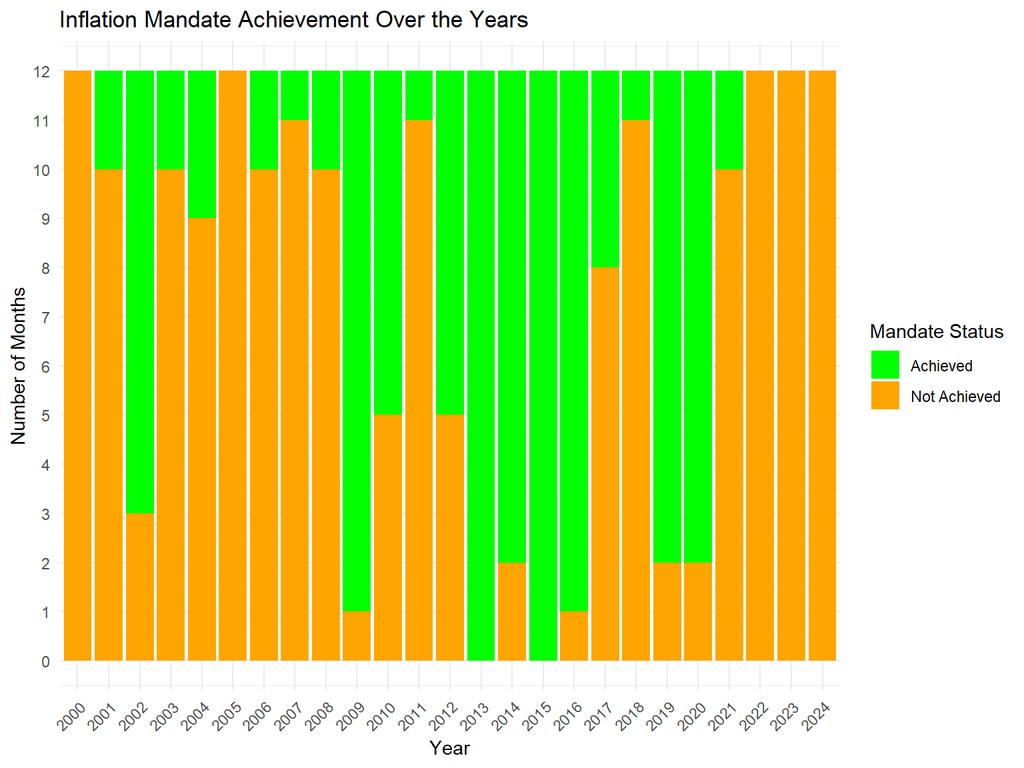

```r
ggplot(cpi_df, aes(x = factor(Year), fill = inflation_criteria)) +
  geom_bar(position = "stack") +
  scale_fill_manual(values = c("Achieved" = "green", "Not Achieved" = "orange")) +
  scale_y_continuous(breaks = seq(0, 12, by = 1)) +  # Force whole numbers for months
  labs(title = "Inflation Mandate Achievement Over the Years",
       x = "Year",
       y = "Number of Months",
       fill = "Mandate Status") +
  theme_minimal() +
  theme(axis.text.x = element_text(angle = 45, hjust = 1))  # Rotate x-axis labels for readability
```

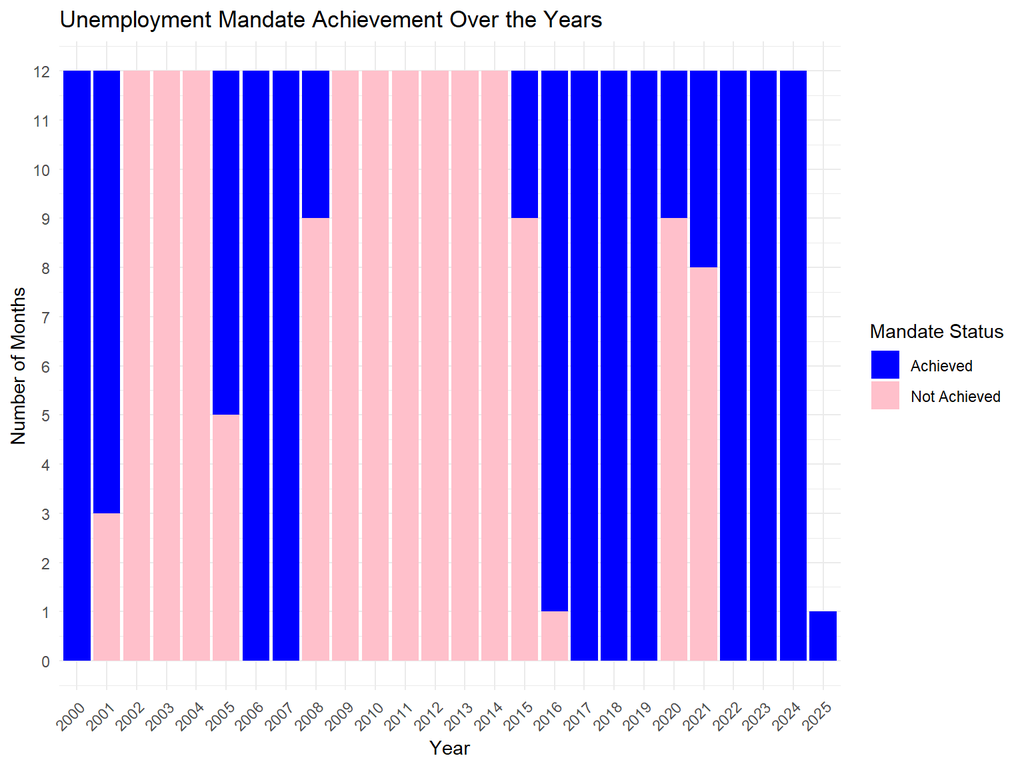

```r
ggplot(unemp_df, aes(x = factor(Year), fill = unemp_criteria)) +
  geom_bar(position = "stack") +
  scale_fill_manual(values = c("Achieved" = "blue", "Not Achieved" = "pink")) +
  scale_y_continuous(breaks = seq(0, 12, by = 1)) +  # Ensure y-axis is in whole numbers (0 to 12)
  labs(title = "Unemployment Mandate Achievement Over the Years",
       x = "Year",
       y = "Number of Months",
       fill = "Mandate Status") +
  theme_minimal() +
  theme(axis.text.x = element_text(angle = 45, hjust = 1))  # Rotate x-axis labels
```

# Ensure merged_df is Properly Structured

```r
# Load necessary libraries
library(dplyr)
library(ggplot2)
library(tidyr)

# Ensure the Month column is a character type
merged_df <- merged_df %>%
  mutate(Month = as.character(Month))

# Convert to long format for better visualization
long_df <- merged_df %>%
  pivot_longer(cols = c(inflation_criteria, unemp_criteria),
               names_to = "Mandate",
               values_to = "Status")

# Rename "Mandate" column for clarity
long_df <- long_df %>%
  mutate(Mandate = ifelse(Mandate == "inflation_criteria", "Inflation Mandate", "Unemployment Mandate"))
```

# Create the Stacked Bar Chart

# Now visualizing combined Inflation & Unemployment Mandate Achievements over the years.

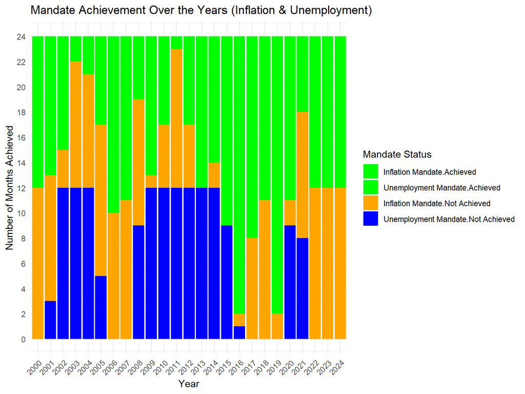

```r
# Define custom colors for each category
colors <- c("Inflation Mandate.Achieved" = "green",
            "Inflation Mandate.Not Achieved" = "orange",
            "Unemployment Mandate.Achieved" = "green",
            "Unemployment Mandate.Not Achieved" = "blue")

# Create the stacked bar chart
ggplot(long_df, aes(x = factor(Year), fill = interaction(Mandate, Status))) +
  geom_bar(position = "stack") +
  scale_fill_manual(values = colors) +
  scale_y_continuous(breaks = seq(0, 24, by = 2)) +  # Ensure whole number scale for months
  labs(title = "Mandate Achievement Over the Years (Inflation & Unemployment)",
       x = "Year",
       y = "Number of Months Achieved",
       fill = "Mandate Status") +
  theme_minimal() +
  theme(axis.text.x = element_text(angle = 45, hjust = 1))  # Rotate x-axis labels for readability
```

### Explanation of the Visualization

Each Year is on the X-axis.

Y-axis represents months (0–12 per mandate, up to 24 total).

Stacked bars show whether mandates were Achieved or Not Achieved:

Green → Achieved (for both inflation & unemployment) Blue → Unemployment Not Achieved Orange → Inflation Not Achieved

# Final Outcome

This clearly illustrates how well the FED has met its dual mandate over time, highlighting patterns in inflation and unemployment stability.